# hist-4916

## Introduction

This Jupyter notebook aims to be reflective of the Ottawa Billings Family, and shows significant events that occurred to them as well as in Ottawa in contrast to Canada's historical events. Together, this shows a progress within the city of Ottawa in accordance to the rest of the country, in order to develop an understanding of how local historical events can be connected to the country's signficant milestones, in order to gather a deeper understanding of Canada's capital.

Below is a set of data in the form of a timeline retrieved from the City of Ottawa's Archives under the department of Arts, Heritage and Events. The Billings Estate is signficant to Ottawa, as it reflects a middle-upper class family and their settlement in the city as the country was developing into the Canada we are familiar with in the 21st century. From being able to review key figures within the Billings family and recongize the other national historic events that occurred within or rather around the same time, we're able to see how Canada was able to develop in accordance to its' Capital City.

### Data

Below is the introduction to the data set being used for the journal. This dataset is an edited CSV file of important dates for Ottawa's society at the time, whether it is regarding the Billings family or the development of the city such as the construction of Parliament while it is contrasted to important national events for the country. The years range from 1857-1983, with the 'Year' header regarding the events in Canada and the 'Year.1' header regarding the events local to Ottawa. The 'NaN' labels mean that although an important event took place in either the Nation or the Capital, there was an absence of an event happening elsewhere.

Additionally, the data imported has quite a messy formatting while additionally summarizing the data, which becomes a little clearer further down! However, we can gather from the data presented below that the Constitution Act was introduced in 1982, however, the following year column reads "NaN', and when we see which 'Billings' column would align with 1982, we can see that nothing was noted to be significant within Ottawa's constructed for the time.

```python
import pandas
import numpy as np
import matplotlib.pyplot as plt
```

```python
import pandas as pd
df = pd.read_csv("newtime copy.csv")
print(df)
```

```
   Emerging City to National Capital (1850-1900)\n\nCANADA  Year Year.1  \
0   New Capital. Ottawa became the\ncapital of the...       1857   1857
1                 Colony of British Columbia Created.       1858   1858
2   Parliament Buildings - Construction began on t...       1859   1859
3                                                 NaN        NaN   1863
4   The Daily News published Ottawa’s first daily ...        NaN   1864
..                                                ...        ...    ...
57                                                NaN        NaN   1975
58  Charles Joseph Clark, Progressive Conservative...       1979   1979
59  Assembly of First Nations. \nAboriginal Chiefs...       1980   1980
60  The Constitution Act, also called the Canada A...       1982    NaN
61  All provinces except for Quebec signed the Con...       1983   1983

                                             Billings
0                           Ottawa’s population 7,760
1   Samuel promoted to Major in Militia. Charles b...
2                        Charles Murray Billings born
3   The first paid police force established in Ott...
4   Death of Braddish Billings.\nLamira II inherit...
..                                                ...
57  Death of Charles A. Billings \n1975 Billings E...
58                 Death of Beatrice Lindsay Billings
59  Terry Fox arrived in Ottawa on July 1st, durin...
60                                                NaN
61  Billings Estate declared a National Historic s...

[62 rows x 4 columns]
```

As we can see below, there is an abundance of information that is quite descriptive being piled on top of one another. In an attempt to organize the data, the columns and rows are further seperated to distinguish what event took place in what year. Below it outlines the events that took place with the corresponding year alongside the event. However, we are looking at FAR too much data to deal with, so we can simplify it further before transforming it

```python
## Reading Headers
print(df.columns)

## Reading Correlating Columns
print (df[['Emerging City to National Capital (1850-1900)\n\nCANADA', 'Year']])
print (df[['Billings', 'Year.1']])

## Reading Each Row
print(df.iloc[10:3])
print (df.iloc[10:3])
for index, row in df.iterrows():
    print(index,row['Billings'])
for index, column in df.iterrows():
    print (index, column['Year'])
```

```
Index(['Emerging City to National Capital (1850-1900)\n\nCANADA', 'Year',
       'Year.1', 'Billings'],
      dtype='object')
   Emerging City to National Capital (1850-1900)\n\nCANADA  Year
0   New Capital. Ottawa became the\ncapital of the...       1857
1                 Colony of British Columbia Created.       1858
2   Parliament Buildings - Construction began on t...       1859
3                                                 NaN        NaN
4   The Daily News published Ottawa’s first daily ...        NaN
..                                                ...        ...
57                                                NaN        NaN
58  Charles Joseph Clark, Progressive Conservative...       1979
59  Assembly of First Nations. \nAboriginal Chiefs...       1980
60  The Constitution Act, also called the Canada A...       1982
61  All provinces except for Quebec signed the Con...       1983
```

[output cut: 184 more lines]

```python
df.loc[df['Billings'] =='Year.1']
df.loc[df['Emerging City to National Capital (1850-1900)\n\nCANADA']== 'Year']
print (df.iloc[4:63])
```

[output not shown]

### Organization of Dataset

Below, we have been able to provide a code that further organizes and displays our data in a fashion that is far less cluttered and is just a fragment of the information within the dataset - making it perfect to display on a graph. We can see how the dates are intended to correspond to the events, and where information may be absent yet reflects an important event either nationally or locally. For this notebook, we will be aiming to graph two events that display correlation or isolation from the other points on the graph, thus correlation or isolation from contributions to the developing Ottawa and/or Canada.

```python
df.sort_values(['Billings', 'Year.1'], ascending=True)
```

[output not shown]

```python
df.sort_values(['Emerging City to National Capital (1850-1900)\n\nCANADA', 'Year'], ascending=True)
```

|  | Emerging City to National Capital (1850-1900)\n\nCANADA | Year | Year.1 | Billings |
| --- | --- | --- | --- | --- |
| 49 | \nCanada | Year | Year | Billings/Ottawa |
| 28 | \nCanada 1900-1945 | Year | Year | Billings |
| 6 | \nConfederation. The Dominion of Canada offici... | 1867 | 1867 | Lamira I begins teaching again |
| 36 | Agnes MacPhail – first woman elected to Parlia... | 1921 | 1921 | Ottawa’s population reached six figures at 107... |
| 29 | Alberta and Saskatchewan join Canada. | 1905 | 1905 | Hugh Braddish became a justice of the peace |
| ... | ... | ... | ... | ... |
| 44 | NaN | NaN | NaN | NaN |
| 45 | NaN | NaN | NaN | NaN |
| 46 | NaN | NaN | NaN | NaN |
| 47 | NaN | NaN | NaN | NaN |
| 57 | NaN | NaN | 1975 | Death of Charles A. Billings \n1975 Billings E... |

62 rows × 4 columns

### Plotting Relevancy to Ottawa

Below, we have been able to provide a code that further organizes and displays our data in a fashion that is far less cluttered and is just a fragment of the information within the dataset - making it perfect to display on a scatterplot graph. The scatterplot provides a simplistic visual to see where events are isolated or correlate with one another, as the grid will either intersect or be seperate from the observed plot. We can see how the dates are intended to correspond to the events, and where information may be absent yet reflects an important event either nationally or locally. For this notebook, we will be aiming to graph two events that display correlation or isolation from the other points on the graph, thus correlation or isolation from contributions to the developing Ottawa and/or Canada.

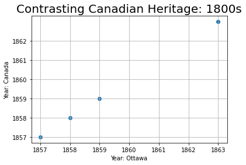

```python
x = [1857, 1858, 1859, 1863]
y = [1857, 1858, 1859,1863]
plt.scatter (x,y)
plt.grid()

plt.title('Contrasting Canadian Heritage: 1800s', fontdict={'fontsize':20})
plt.xlabel('Year: Ottawa')
plt.ylabel('Year: Canada')

plt.xticks ([1857, 1858, 1859,1860, 1861, 1862, 1863])
plt.yticks ([1857, 1858, 1859, 1860, 1861, 1862])

plt.show()
```

From the scatter plot with the grid, we are able to see where events collide in the capital with events that have simultaneously occurred with events that have happened in the country. The furthest dot above indicates Ottawa's first funded police force, which we can see as an isolated variable, being as it is the furthest in time from the other events. Additionally, the dot is isolated as it does not correspond with the Canadian timeline of years located in the y-axis. From this smaller local event, we can infer the event of Ottawa's police force being established has no direct correlation to the development of Canada as a country during the year of 1863. Therefore, we can state that this particular incident is a weakness within the data, which we can further research or conclude it is not relevant to developments towards Canada and Ottawa simultaneously.

### Plotting the Relevancy of Canada with Ottawa

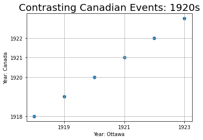

```python
x = [1918, 1919, 1920, 1921, 1922, 1923]
y = [1918, 1919, 1920, 1921, 1922, 1923]
plt.scatter (x,y)
plt.grid()

plt.title('Contrasting Canadian Events: 1920s', fontdict={'fontsize':20})
plt.xlabel('Year: Ottawa')
plt.ylabel('Year: Canada')

plt.xticks ([1919, 1921, 1923])
plt.yticks ([1918, 1920, 1921, 1922])

plt.show()
```

With 1921 being the only year that is intersecting with each graph, we are able to see that these events occurred simultaneously within Canada and Ottawa. This can prove to show potential strength within the dataset, as we are able to further investigate whether the development of cities such as Ottawa during the time can contribute to the societal shift of a woman in Parliament (which if we were to critically analyse the Sufferage Movement, we might be onto something!). Further, this graph showing the correlation of the events can prompt further research into the simultaneous nature of these seperate events.

### Conclusion

From the tables and graphs above, we are able to conclude that events that pertain to Ottawa and Canada can show significant shifts within government, society and ways of life that we are familiarized with today. With events such as the development of the police force we can infer that when the isolated events occur that do not affect Canada as a whole, it merely contributes to the development of the city. However, events that are isolated and synonymous are still significant to provide further insights to either the development of Canada or Ottawa seperately, which can further aid GLAM studies in conducting local and national research. In further studies, we can expand on the events that have occurred within Ottawa, being able to provide more detail about the growth of the city, as the dataset reflects mostly upon the Billings Estates. Additionally, we can look at more recent history throughout the 20th century to determine how many more correlated events have contributed to the growth of Ottawa and Canada synonymously.

### References to Sources Utilized

Videos That Helped Construct Coding: https://www.youtube.com/watch?v=vmEHCJofslg&ab_channel=KeithGalli https://www.youtube.com/watch?v=dxueNcTYjqI&ab_channel=CodeWithData

Links that provided much insight: https://www.datacamp.com/community/tutorials/pandas-read-csv?utm_source=adwords_ppc&utm_campaignid=898687156&utm_adgroupid=48947256715&utm_device=c&utm_keyword=&utm_matchtype=b&utm_network=g&utm_adpostion=&utm_creative=332602034343&utm_targetid=aud-392016246653:dsa-429603003980&utm_loc_interest_ms=&utm_loc_physical_ms=9000671&gclid=Cj0KCQjwyN-DBhCDARIsAFOELTmZjqIHGBvKaAcw90FPIqC5dU4GlmsgC8S_6FlBgT0Idv-ybQ4neooaAvZWEALw_wcB

https://jupyterlab.readthedocs.io/en/stable/user/files.html

https://notebook.community/mholtrop/Phys605/Python/Plotting/Plot_from_CSV_data

Link to PDF that shows dataset for the Billings Estate: https://ottawa.ca/en/arts-heritage-and-events/city-ottawa-archives/exhibitions-and-displays/billings-family-virtual-exhibit?fbclid=IwAR12GKYeetFLySyiyDmAPBpc0QjX26QHNqoDokYelBqr3IIQHtUW-45igWc

March, 29, 2021 - Dr. Graham posted about constructing graphs in the 'Building Our Notebooks' Channel on Discord - very helpful!

Additional thanks to peers and friends who were able to help change a comma along the way!

### Further Readings

To further learn about the development of Canada and Ottawa, and the impact on those who have within the city or country, these text provide insight within the datasets and additionally open opportunities to learn more about Canadian/Ottawa historical development:

The Woman Suffrage Movement in Canada: Second Edition by Catherine L. Cleverdon - available on Google Books:https://books.google.ca/books?hl=en&lr=&id=qQDmDQAAQBAJ&oi=fnd&pg=PT44&dq=ottawa+suffrage+women&ots=l-8etKG9LF&sig=esiNT4E7q09VfICs4-EpPCf0Lf0&redir_esc=y#v=onepage&q=ottawa%20suffrage%20women&f=false

BAnQ's Glam Project from 2014 - one of the first in Canada that shows development of street and social life based in Quebec: https://blogues.banq.qc.ca/instantanes/2014/12/17/banq-et-wikimedia-une-premiere-collaboration-glam-au-canada/

Ottawa's Heritage webpage explaining the historical significance of the Billings Family to Ottawa https://heritageottawa.org/50years/billings-estate-house

Canada's reconciliation for framework regarding Canada's Archives https://librarianship.ca/news/reconciliation-framework-archives/